# Coursera Practical ML Project

Tom Poorten

November 22, 2019

## Read in data

```r
# rm(list=ls())
suppressPackageStartupMessages(library(caret))
suppressPackageStartupMessages(library(AppliedPredictiveModeling))
suppressPackageStartupMessages(library(tidyverse))
suppressPackageStartupMessages(library(knitr))

setwd("Z:/Pairwise/DataScience/ELN/tpoorten/learning/")
training.all = read_csv("pml-training.csv", progress = F)
validation = read_csv("pml-testing.csv", progress = F)
```

## Split data into training and testing

```r
# Split data
inTrain = createDataPartition(training.all$classe, p = 0.8, list = F)
training = training.all[inTrain,]
testing = training.all[-inTrain,]
```

## Data preprocessing

Preprocessing steps run on training and testing datasets

- Remove irrelevant variables (index, timestamps) and outcome variable
- Remove variables with near zero variance
- Convert user name variable into numeric
- Filter out non-numeric variables and variables with missing data NAs
- When missing data are present in a variable, most instances are missing, so imputation would probably not work well

```r
# Preprocess
# Remove index, timestamp, and outcome variable
training.vars = training[,!grepl("classe|X1|raw_timestamp_part_1|aw_timestamp_part_2|cvtd_timestamp|new_window|num_window", colnames(training))]
testing.vars = testing[,!grepl("classe|X1|raw_timestamp_part_1|aw_timestamp_part_2|cvtd_timestamp|new_window|num_window", colnames(testing))]

# Near zero variance
nzv <- nearZeroVar(training.vars, saveMetrics= TRUE)
nzv.keep = rownames(nzv)[which(!nzv$nzv)]
training.vars = training.vars %>% select(nzv.keep)
testing.vars = testing.vars %>% select(nzv.keep)

# Create numeric user name variable
training.vars$user_name_num = as.numeric(as.factor(training.vars$user_name))
testing.vars$user_name_num = as.numeric(as.factor(testing.vars$user_name))

# Check out how many missing values in each variable
# apply(training, 2, function(x) table(is.na(x)))
training.vars.nomissing = training.vars %>% select_if(is.numeric) %>% select_if(function(x){!any(is.na(x))})
testing.vars.nomissing = testing.vars %>% select(colnames(training.vars.nomissing))

# Add outcome variable back in
training.vars.nomissing = cbind(training.vars.nomissing, classe = training$classe)
testing.vars.nomissing = cbind(testing.vars.nomissing, classe = testing$classe)
```

## Exploratory Data Analysis - PCA

Run PCA with `prcomp()`

1. Center and scale the data.
2. First run PCA on whole dataset except for outcome variable, and make biplot to show variable contributions to PC1 and PC2. Use outcome ‘classe’ as the color variable.
- Various variables are making substantial contributions to PCs.
- There is no apparent clustering of the ‘classe’ outcome variable, suggesting that simple discriminant analysis would not perform well. More complex ML models (e.g. Random Forest) are likely to perform better.
3. Repeat PCA plot showing ‘user_name’ as the color variable.
- There is a strong clustering pattern associated with user_name, suggesting that each user’s motion metrics are somewhat distinctive.

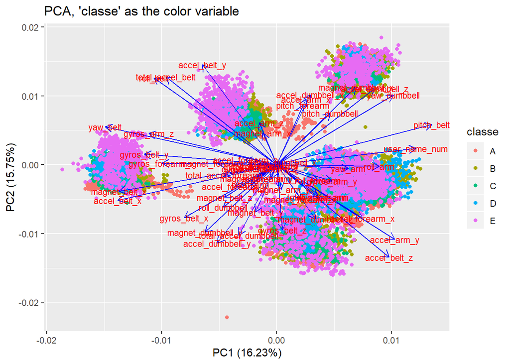

```r
training.vars.nomissing.preproc = preProcess(training.vars.nomissing, method = c("center","scale"))
training.vars.nomissing.preproc = predict(training.vars.nomissing.preproc, training.vars.nomissing)

testing.vars.nomissing.preproc = preProcess(training.vars.nomissing, method = c("center","scale"))
testing.vars.nomissing.preproc = predict(testing.vars.nomissing.preproc, testing.vars.nomissing)

library(ggfortify)
autoplot(prcomp(training.vars.nomissing.preproc[,-c(54)]), data = training,
         colour = 'classe',
         loadings = TRUE, loadings.colour = 'blue',
         loadings.label = TRUE, loadings.label.size = 3, main = "PCA, 'classe' as the color variable")
```

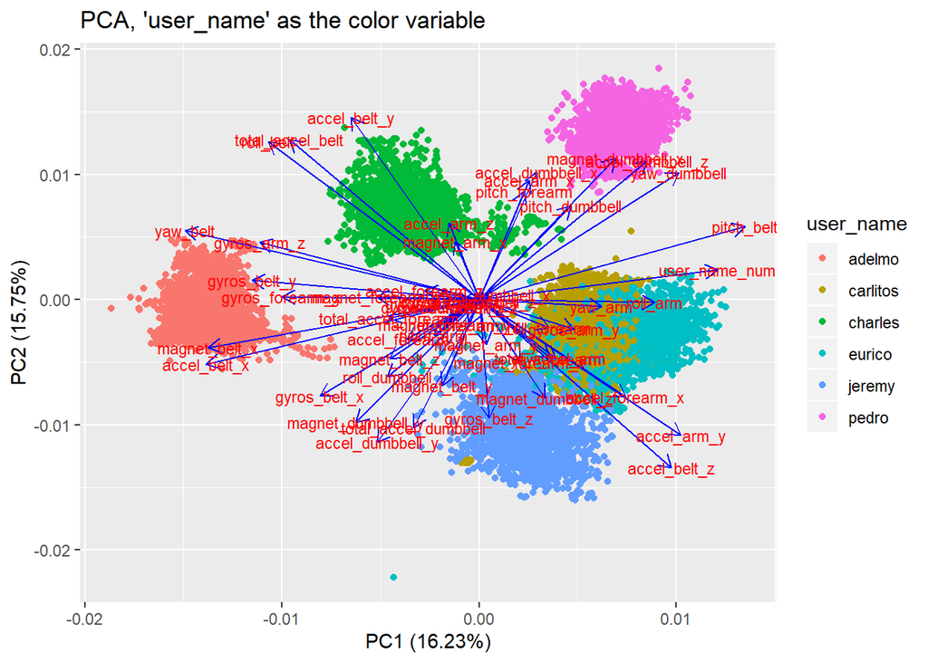

```r
autoplot(prcomp(training.vars.nomissing.preproc[,-c(54)]), data = training,
         colour = 'user_name',
         loadings = TRUE, loadings.colour = 'blue',
         loadings.label = TRUE, loadings.label.size = 3, main = "PCA, 'user_name' as the color variable")
```

## Run Models

- Run several ML models on training dataset with 5 fold cross-validation
- Assess model accurary and error with test dataset

### Linear discriminatic analysis

- Run model
- Display confusion matrix

```r
# Set seed for reproducibility
set.seed(12345)

# Create cross-validation control object
ctrl = trainControl(method = "cv", number = 5)

modFit.lda = train(classe ~ ., method = "lda", data = training.vars.nomissing.preproc, trControl = ctrl)
modFit.lda.pred = predict(modFit.lda, training.vars.nomissing.preproc[,-54])
modFit.lda.accuracy = length(which(modFit.lda.pred == testing.vars.nomissing.preproc$classe)) / length(modFit.lda.pred)
modFit.lda.oos.error = 1 - modFit.lda.accuracy
confusionMatrix(testing.vars.nomissing.preproc$classe, predict(modFit.lda, testing.vars.nomissing.preproc[,-54]))
```

```
## Confusion Matrix and Statistics
##
##           Reference
## Prediction   A   B   C   D   E
##          A 896  27  98  87   8
##          B 119 488  79  32  41
##          C  65  74 438  81  26
##          D  30  27  59 497  30
##          E  30 138  50  66 437
##
## Overall Statistics
##
##                Accuracy : 0.7025
##                  95% CI : (0.6879, 0.7168)
##     No Information Rate : 0.2906
##     P-Value [Acc > NIR] : < 2.2e-16
##
##                   Kappa : 0.6238
##
##  Mcnemar's Test P-Value : < 2.2e-16
##
## Statistics by Class:
##
##                      Class: A Class: B Class: C Class: D Class: E
## Sensitivity            0.7860   0.6472   0.6050   0.6514   0.8063
## Specificity            0.9209   0.9145   0.9231   0.9538   0.9160
## Pos Pred Value         0.8029   0.6430   0.6404   0.7729   0.6061
## Neg Pred Value         0.9131   0.9159   0.9117   0.9189   0.9672
## Prevalence             0.2906   0.1922   0.1846   0.1945   0.1382
## Detection Rate         0.2284   0.1244   0.1116   0.1267   0.1114
## Detection Prevalence   0.2845   0.1935   0.1744   0.1639   0.1838
## Balanced Accuracy      0.8535   0.7808   0.7640   0.8026   0.8611
```

### Quadratic discriminant analysis

- Run model
- Display confusion matrix

```r
modFit.qda = train(classe ~ ., method = c("qda"), data = training.vars.nomissing.preproc, trControl = ctrl)
modFit.qda.pred = predict(modFit.qda, testing.vars.nomissing.preproc[,-54])
modFit.qda.accuracy = length(which(modFit.qda.pred == testing.vars.nomissing.preproc$classe)) / length(modFit.qda.pred)
modFit.qda.oos.error = 1 - modFit.qda.accuracy
confusionMatrix(testing.vars.nomissing.preproc$classe, predict(modFit.qda, testing.vars.nomissing.preproc[,-54]))
```

```
## Confusion Matrix and Statistics
##
##           Reference
## Prediction    A    B    C    D    E
##          A 1033   46   18   16    3
##          B   42  636   66    3   12
##          C    0   38  641    2    3
##          D    0    1   64  570    8
##          E    0   20   21   17  663
##
## Overall Statistics
##
##                Accuracy : 0.9031
##                  95% CI : (0.8934, 0.9122)
##     No Information Rate : 0.274
##     P-Value [Acc > NIR] : < 2.2e-16
##
##                   Kappa : 0.8777
##
##  Mcnemar's Test P-Value : < 2.2e-16
##
## Statistics by Class:
##
##                      Class: A Class: B Class: C Class: D Class: E
## Sensitivity            0.9609   0.8583   0.7914   0.9375   0.9623
## Specificity            0.9709   0.9613   0.9862   0.9780   0.9821
## Pos Pred Value         0.9256   0.8379   0.9371   0.8865   0.9196
## Neg Pred Value         0.9850   0.9668   0.9478   0.9884   0.9919
## Prevalence             0.2740   0.1889   0.2065   0.1550   0.1756
## Detection Rate         0.2633   0.1621   0.1634   0.1453   0.1690
## Detection Prevalence   0.2845   0.1935   0.1744   0.1639   0.1838
## Balanced Accuracy      0.9659   0.9098   0.8888   0.9577   0.9722
```

### Naive Bayes model

- Run model
- Display confusion matrix

```r
modFit.nb = train(classe ~ ., method = "naive_bayes", data = training.vars.nomissing.preproc, trControl = ctrl)
modFit.nb.pred = predict(modFit.nb, testing.vars.nomissing.preproc[,-54])
modFit.nb.accuracy = length(which(modFit.nb.pred == testing.vars.nomissing.preproc$classe)) / length(modFit.nb.pred)
modFit.nb.oos.error = 1 - modFit.nb.accuracy

confusionMatrix(testing.vars.nomissing.preproc$classe, predict(modFit.nb, testing.vars.nomissing.preproc[,-54]))
```

```
## Confusion Matrix and Statistics
##
##           Reference
## Prediction   A   B   C   D   E
##          A 992  20  30  63  11
##          B 151 513  46  36  13
##          C 162  50 443  28   1
##          D 112   1  73 421  36
##          E  36  68  26  28 563
##
## Overall Statistics
##
##                Accuracy : 0.7474
##                  95% CI : (0.7335, 0.7609)
##     No Information Rate : 0.3704
##     P-Value [Acc > NIR] : < 2.2e-16
##
##                   Kappa : 0.6768
##
##  Mcnemar's Test P-Value : < 2.2e-16
##
## Statistics by Class:
##
##                      Class: A Class: B Class: C Class: D Class: E
## Sensitivity            0.6827   0.7868   0.7168   0.7309   0.9022
## Specificity            0.9498   0.9248   0.9271   0.9337   0.9521
## Pos Pred Value         0.8889   0.6759   0.6477   0.6547   0.7809
## Neg Pred Value         0.8358   0.9561   0.9460   0.9527   0.9809
## Prevalence             0.3704   0.1662   0.1575   0.1468   0.1591
## Detection Rate         0.2529   0.1308   0.1129   0.1073   0.1435
## Detection Prevalence   0.2845   0.1935   0.1744   0.1639   0.1838
## Balanced Accuracy      0.8163   0.8558   0.8220   0.8323   0.9272
```

### Classification tree

- Run CART model
- Display confusion matrix and decision tree

```r
modFit.rpart = train(classe ~ ., method = "rpart", data = training.vars.nomissing.preproc, trControl = ctrl)
modFit.rpart.pred = predict(modFit.rpart, testing.vars.nomissing.preproc[,-54])
modFit.rpart.accuracy = length(which(modFit.rpart.pred == testing.vars.nomissing.preproc$classe)) / length(modFit.rpart.pred)
modFit.rpart.oos.error = 1 - modFit.rpart.accuracy

confusionMatrix(testing.vars.nomissing.preproc$classe, predict(modFit.rpart, testing.vars.nomissing.preproc[,-54]))
```

```
## Confusion Matrix and Statistics
##
##           Reference
## Prediction   A   B   C   D   E
##          A 990  15  91   0  20
##          B 323 255 181   0   0
##          C 311  28 345   0   0
##          D 276 137 230   0   0
##          E  85 102 186   0 348
##
## Overall Statistics
##
##                Accuracy : 0.494
##                  95% CI : (0.4782, 0.5098)
##     No Information Rate : 0.506
##     P-Value [Acc > NIR] : 0.9353
##
##                   Kappa : 0.3398
##
##  Mcnemar's Test P-Value : NA
##
## Statistics by Class:
##
##                      Class: A Class: B Class: C Class: D Class: E
## Sensitivity            0.4987   0.4749  0.33398       NA  0.94565
## Specificity            0.9350   0.8512  0.88270   0.8361  0.89508
## Pos Pred Value         0.8871   0.3360  0.50439       NA  0.48266
## Neg Pred Value         0.6455   0.9109  0.78759       NA  0.99375
## Prevalence             0.5060   0.1369  0.26332   0.0000  0.09381
## Detection Rate         0.2524   0.0650  0.08794   0.0000  0.08871
## Detection Prevalence   0.2845   0.1935  0.17436   0.1639  0.18379
## Balanced Accuracy      0.7169   0.6630  0.60834       NA  0.92036
```

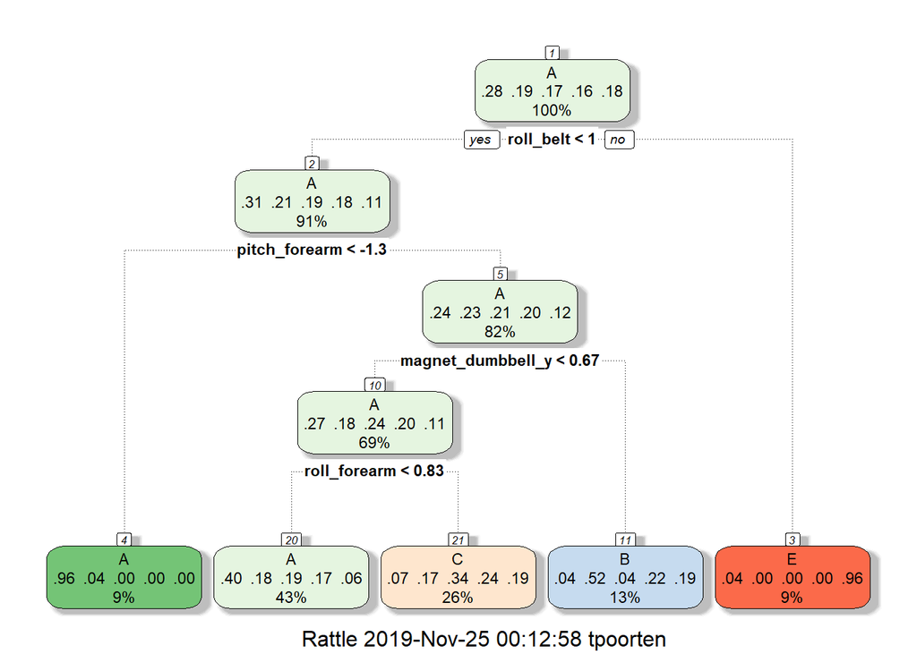

```r
suppressPackageStartupMessages(library(rattle))
fancyRpartPlot(modFit.rpart$finalModel)
```

### Random Forest

- Run model
- Display confusion matrix
- Display plot showing #Randomly Selected Predictors vs. Accuracy
- Show variable importance bar plot

```r
# Long run time, save results for Rmd report generation
# modFit.rf = train(classe ~ ., method = "rf", data = training.vars.nomissing.preproc, trControl = ctrl)
# save(list = c("modFit.rf"), file = "MLproj_RandomForest.Rdata")
load(file = "MLproj_RandomForest.Rdata")
modFit.rf.pred = predict(modFit.rf, testing.vars.nomissing.preproc[,-54])
modFit.rf.accuracy = length(which(modFit.rf.pred == testing.vars.nomissing.preproc$classe)) / length(modFit.rf.pred)
modFit.rf.oos.error = 1 - modFit.rf.accuracy

confusionMatrix(testing.vars.nomissing.preproc$classe, predict(modFit.rf, testing.vars.nomissing.preproc[,-54]))
```

```
## Confusion Matrix and Statistics
##
##           Reference
## Prediction    A    B    C    D    E
##          A 1116    0    0    0    0
##          B    1  758    0    0    0
##          C    0    0  682    2    0
##          D    0    0    3  640    0
##          E    0    0    0    2  719
##
## Overall Statistics
##
##                Accuracy : 0.998
##                  95% CI : (0.996, 0.9991)
##     No Information Rate : 0.2847
##     P-Value [Acc > NIR] : < 2.2e-16
##
##                   Kappa : 0.9974
##
##  Mcnemar's Test P-Value : NA
##
## Statistics by Class:
##
##                      Class: A Class: B Class: C Class: D Class: E
## Sensitivity            0.9991   1.0000   0.9956   0.9938   1.0000
## Specificity            1.0000   0.9997   0.9994   0.9991   0.9994
## Pos Pred Value         1.0000   0.9987   0.9971   0.9953   0.9972
## Neg Pred Value         0.9996   1.0000   0.9991   0.9988   1.0000
## Prevalence             0.2847   0.1932   0.1746   0.1642   0.1833
## Detection Rate         0.2845   0.1932   0.1738   0.1631   0.1833
## Detection Prevalence   0.2845   0.1935   0.1744   0.1639   0.1838
## Balanced Accuracy      0.9996   0.9998   0.9975   0.9964   0.9997
```

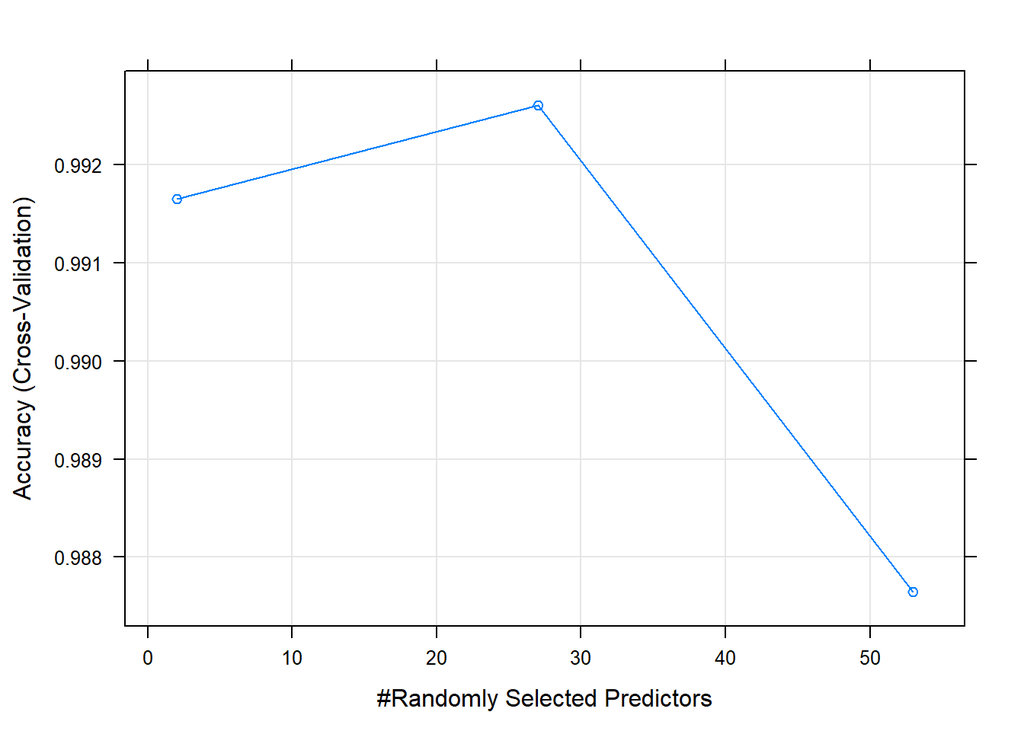

```r
plot(modFit.rf)
```

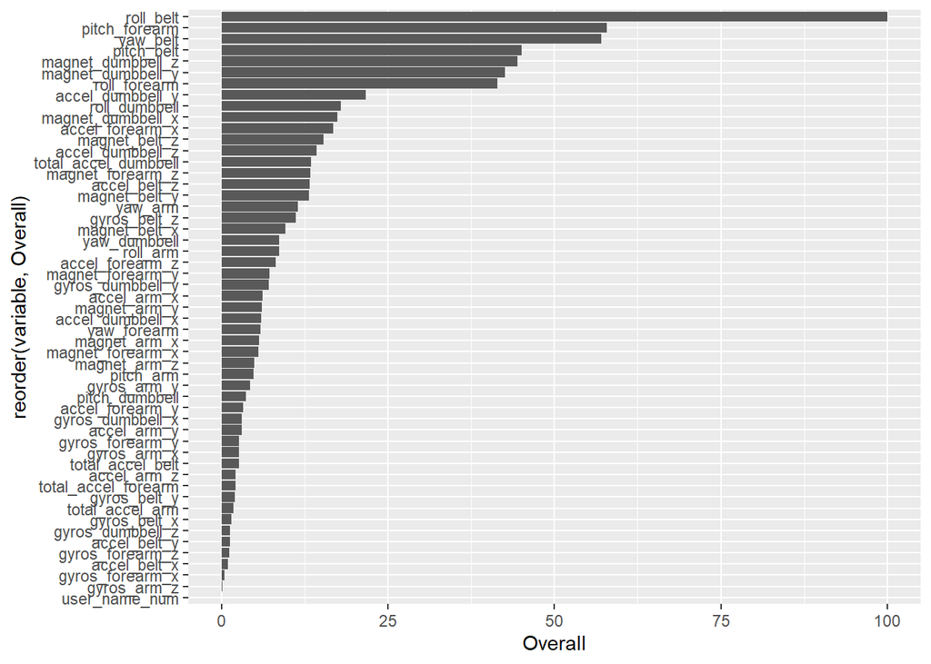

```r
modFit.rf.varImportance = varImp(modFit.rf)$importance
modFit.rf.varImportance$variable = rownames(modFit.rf.varImportance)

ggplot(modFit.rf.varImportance, aes(reorder(variable, Overall), Overall)) +
  geom_bar(stat="identity") +
  # theme(axis.text.x = element_text(angle = 90, hjust = 1)) +
  coord_flip()
```

## Model Comparison

As summarized in the table below, the Random Forest model performed the best out of all the ML models tested in this analysis with the lowest out of sample error.

[output not shown]